# 0228

```r
#####
# set up the environment
#####
# load packages
library(rethinking)
options(mc.cores = parallel::detectCores())
rstan_options(auto_write = TRUE)

# adjust the plot region for viewing on the projector in class
options(repr.plot.height=5)
```

[output not shown]

## Random intercept models

Random intercept models are the simplest form of random-effects models (or multilevel models). They allow you to say that each group has a different average outcome, but that the relationship between the outcome and the covariates is invariant across groups.

Multilevel (hierarchical) models also provide a framework for interpreting the change in an outcome variable as it relates to covariates at the level of both the individual observation and of the group. We will look at both cases here, in relation to reading test scores among grade-one students.

This time, we will use all of the grade-one data in the Tennessee STAR data set, which has over 6000 students in more than 300 classes.

```r
d <- read.csv("https://mcmahanp.github.io/soci620/data/t_star_student_grade1.csv")
head(d)
```

| student_id | teacher_id | class_type | class_size | born | female | race_ethnicity | re_white | re_black | re_asian | re_hispanic | re_native_american | re_other | reading_score | math_score | listening_score |
| --- | --- | --- | --- | --- | --- | --- | --- | --- | --- | --- | --- | --- | --- | --- | --- |
| 1 | 1 | 3 | 23 | 1979.058 | FALSE | White | TRUE | FALSE | FALSE | FALSE | FALSE | FALSE | 516 | 578 | 601 |
| 2 | 2 | 2 | 22 | 1980.404 | FALSE | White | TRUE | FALSE | FALSE | FALSE | FALSE | FALSE | 451 | 507 | 584 |
| 3 | 3 | 2 | 21 | 1979.307 | TRUE | Black | FALSE | TRUE | FALSE | FALSE | FALSE | FALSE | 483 | 526 | 529 |
| 4 | 4 | 3 | 21 | 1980.322 | FALSE | Black | FALSE | TRUE | FALSE | FALSE | FALSE | FALSE | 516 | 505 | 556 |
| 5 | 4 | 3 | 21 | 1978.416 | TRUE | Black | FALSE | TRUE | FALSE | FALSE | FALSE | FALSE | 433 | 463 | 504 |
| 6 | 5 | 3 | 29 | 1980.648 | TRUE | Black | FALSE | TRUE | FALSE | FALSE | FALSE | FALSE | 444 | 542 | 543 |

```r
# create a consistent class index
reindex_1 <- function(x){
    # re-index an id x to exactly 1:length(x)
    x_old <- unique(as.character(x))
    x_old <- x_old[!is.na(x_old)]
    x_new <- seq(length(x_old))
    names(x_new) <- x_old
    return(x_new[as.character(x)])
}
```

We will start with an intercept-only model, which will provide the scaffolding for including covariates. This will look very similar to the fixed-effects model from the previous lab, but will have the hyperparameters for the prior on `a` determined by the data rather than as a prior.

```r
m1 <- alist(
    reading_score ~ dnorm(mu,sigma),
    mu <- a[class_id],
    a[class_id] ~ dnorm(gamma,phi),
    sigma ~ dunif(0,100),
    gamma ~ dnorm(500,100),
    phi ~ dunif(0,100)
)

# make a new dataset with complete cases
dta <- d[complete.cases(d[c('reading_score')]),]
# re-index class_id to keep it consistent
dta$class_id <- reindex_1(dta$teacher_id)


fit1 <- map2stan(m1,data=dta)
```

```
[ 1000 / 1000 ]
```

```r
precis(fit1,prob=.9,depth=1)
```

```
334 vector or matrix parameters omitted in display. Use depth=2 to show them.
```

```
        Mean StdDev lower 0.9 upper 0.9 n_eff Rhat
sigma  47.28   0.45     46.55     48.02  2534    1
gamma 521.86   1.64    519.04    524.39  1910    1
phi    28.81   1.22     26.82     30.94  1425    1
```

Even without predictor variables, this model shows us that there is a significant amount of between-class variation (as estimated in `phi`).

### Including student-level covariates

We will start by seeing how students' age affects their test scores, taking into account inter-class variation.

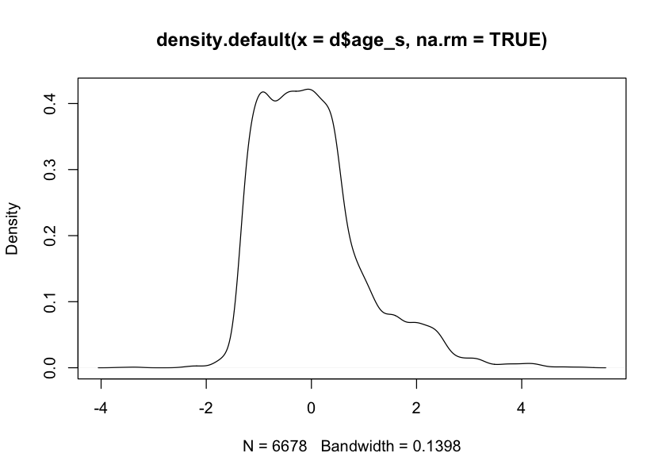

```r
# construct a standardized age variable from the `born` variable
st <- function(x){
    (x-mean(x,na.rm=TRUE))/sd(x,na.rm=TRUE)
}

d$age_s <- st(-d$born)
plot(density(d$age_s,na.rm=TRUE))
```

```r
# build and estimate the model
m2 <- alist(
    reading_score ~ dnorm(mu,sigma),
    mu <- b_0[class_id] + b_age*age_s, # age is included in the level-one model
    b_0[class_id] ~ dnorm(gamma,phi),
    b_age ~ dnorm(0,50),
    sigma ~ dunif(0,100),
    gamma ~ dnorm(500,100),
    phi ~ dunif(0,100)
)

# make a new dataset with complete cases
dta <- d[complete.cases(d[c('reading_score','age_s')]),]
# re-index class_id to keep it consistent
dta$class_id <- reindex_1(dta$teacher_id)


fit2 <- map2stan(m2,data=dta)
```

```
[ 1000 / 1000 ]
```

```r
precis(fit2,prob=.9)
```

```
334 vector or matrix parameters omitted in display. Use depth=2 to show them.
```

```
        Mean StdDev lower 0.9 upper 0.9 n_eff Rhat
b_age  -5.37   0.63     -6.46     -4.40  2842    1
sigma  47.03   0.45     46.23     47.70  2449    1
gamma 521.62   1.69    519.08    524.63  1801    1
phi    28.68   1.27     26.39     30.52  1492    1
```

Age has a negative relationship with test scores: or every increase of one standard deviation increase in age, the model predicts that student will score about five points lower.

### Including class-level covariates

Very often, it is important to be able to look at the relationship between an outcome variable and a covariate that only varies at the group level. This is exactly the case in the STAR data if we are interested in the effect of the experimental treatment. Do smaller classes lead to better test scores? A model that estimates this effect, allowing between-class variation inn average scores, be written mathematically (omitting priors for now) as

$$S_{ik} \sim \mathrm{Norm}(\mu_{ik},\sigma)\\ \mu_{ik} = \beta_{0k} + \beta_{1}Age_i\\ \\ \beta_{0k} = \gamma_{0} + \gamma_1Small_k+ \eta_{0k}\\ \eta_{0k} \sim \mathrm{Norm}(0, \phi_0)$$

To make the model easier to specify, note that we can substitute $\beta_{0k}$ into the individual-level linear model and rearrange, giveing us

$$S_{ik} \sim \mathrm{Norm}(\mu_{ik},\sigma)\\ \mu_{ik} = \beta_{0k} +\gamma_1Small_k+ \beta_{1}Age_i\\ \\ \beta_{0k} \sim \mathrm{Norm}(\gamma_0, \phi_0)$$

```r
# build and estimate the model
m3 <- alist(
    reading_score ~ dnorm(mu,sigma),
    mu <- b_0[class_id] + gamma_small*small + b_age*age_s,
    b_0[class_id] ~ dnorm(gamma_0,phi),
    b_age ~ dnorm(0,50),
    gamma_small <- dnorm(0,50),
    sigma ~ dunif(0,100),
    gamma_0 ~ dnorm(500,100),
    phi ~ dunif(0,100)
)

# make a new dataset with complete cases
dta <- d[complete.cases(d[c('reading_score','age_s','small')]),]
# re-index class_id to keep it consistent
dta$class_id <- reindex_1(dta$teacher_id)

fit3 <- map2stan(m3,data=dta)
```

[output not shown]

```r
precis(fit3,prob=.9)
```

[output not shown]